# Ejercicio 7

Ricardo Lastra

07 de Noviembre de 2017

Producción de leche (Congdon, 2001). Se tienen los datos anuales de producción de leche (Yt) en lbs109, y número de vacas (xt) en unidades106, en el período de 1970 a 1982.

El modelo sugerido para estos datos es: para t1,2,…,13

$$Observación:\ Y_{t}=\beta_{t}x_+\epsilon_{t},\epsilon_{t} \thicksim N(0,V^{-1}) \Rightarrow Y_{t} \thicksim N(\beta_t x_t,V^{-1}) \\
Evolución:\ \beta_{t}=\beta_{t-1}+\omega_{t},\omega_{t} \thicksim N(0,W^{-1}) \Rightarrow \beta_{t} \thicksim N(\beta_{t-1},W^{-1}) \\$$

Además sugieren una varianza constante V1 y W0.05.

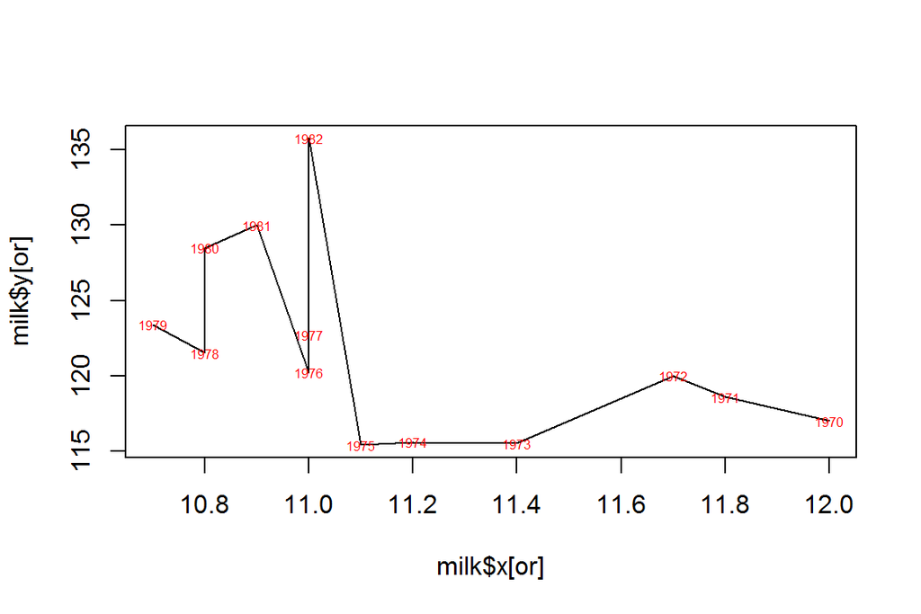

```r
#By Ricardo Lastra
#Usamos en este ejercicio R2Jags
#install.packages("R2jags")
library(R2jags)

wdir<-getwd()
setwd(wdir)

#-------Funciones utiles----------
prob <- function(x){
  out <- min(length(x[x>0])/length(x),length(x[x<0])/length(x))
  out
}

#-Reading data-
milk<-read.table("http://allman.rhon.itam.mx/~lnieto/index_archivos/milk.txt",header=TRUE)
milk$t<-1970:1982
n<-nrow(milk)
or<-order(milk$x)
plot(milk$x[or],milk$y[or],type="l")
text(milk$x[or],milk$y[or],labels=milk$t[or],cex=0.5,col=2)
```

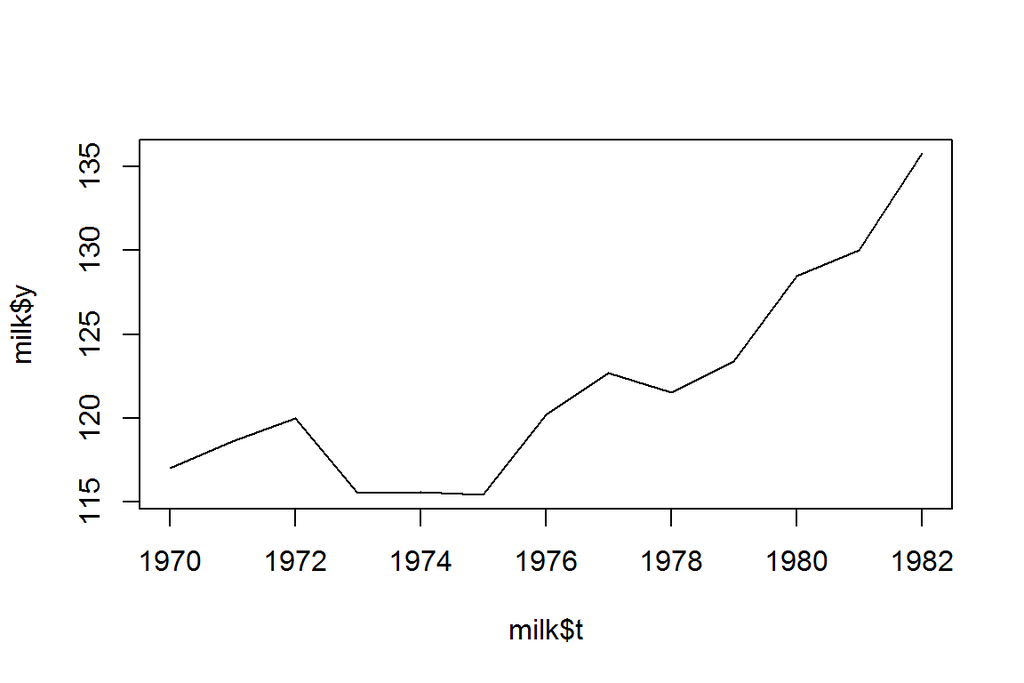

```r
plot(milk$t,milk$y,type="l")
```

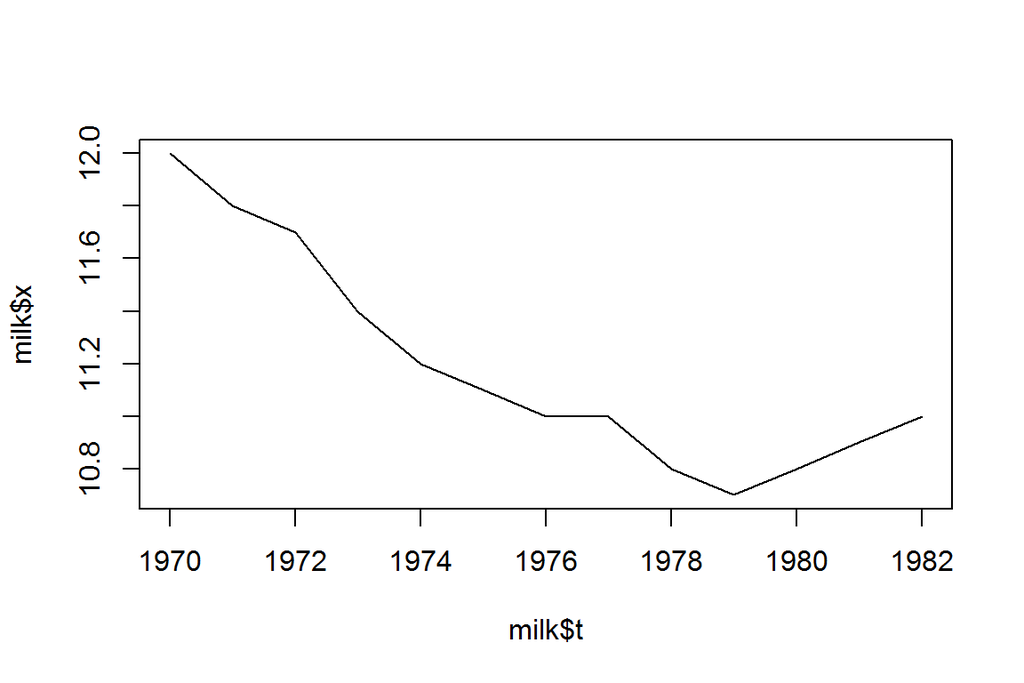

```r
plot(milk$t,milk$x,type="l")
```

```r
#-Defining data-
m<-2
data<-list("n"=n,"m"=m,"y"=scale(milk$y)[1:n],"x"=scale(milk$x)[1:n],"t"=scale(milk$t)[1:n])
```

### Ejercicio B)

Se pide realizar un ejercicio quitando y poniendo “0” en las distribuciones iniciales, donde se piensa que con esto ya no habra diferencia en los resultados del modelo normal y gamma.

Modelo:

```r
inits<-function(){list(beta=rep(0,n+m),tau.y=1,yf1=rep(0,n+m))}
parameters<-c("beta","tau.y","tau.b","yf1")
ej7b.sim<-jags(data,inits,parameters,model.file="Ej7b.txt",
               n.iter=50000,n.chains=1,n.burnin=5000,n.thin=1)
```

Usando:

model { Likelihood Space eq. for (i in 1:n) { y[i] ~ dnorm(mu[i],tau.y) mu[i]<-beta[i] } State eq. for (i in 2:n) { beta[i] ~ dnorm(mu.b[i],tau.b) mu.b[i] <- beta[i-1] } Priors beta[1] ~ dnorm(0,0.001) tau.b<- lam*tau.y lam<-0.01 tau.y ~ dgamma(0.001,0.001)

Prediction 1:

for (i in 1:n) { yf1[i] ~ dnorm(mu[i],tau.y) }

Prediction 2:

for (i in (n+1):(n+m)) { yf1[i] ~ dnorm(mu[i],tau.y) mu[i] <- beta[i] beta[i] ~ dnorm(mu.b[i],tau.b) mu.b[i] <- beta[i-1] }

}

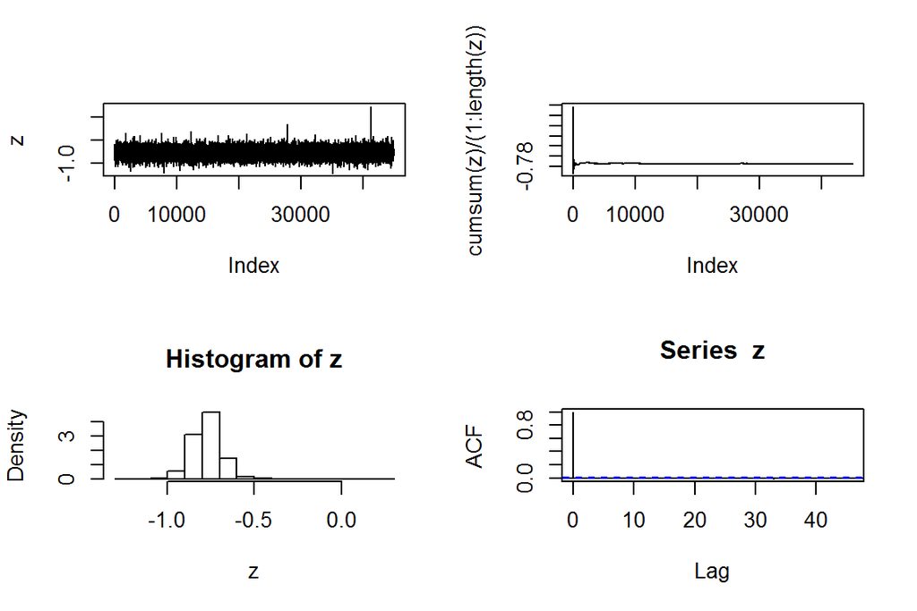

```r
out<-ej7b.sim$BUGSoutput$sims.list

z<-out$yf1[,1]
par(mfrow=c(2,2))
plot(z,type="l")
plot(cumsum(z)/(1:length(z)),type="l")
hist(z,freq=FALSE)
acf(z)
```

```r
#Resumen de estimadores
out.sum<-ej7b.sim$BUGSoutput$summary
#Tabla resumen
out.sum.t<-out.sum[grep("beta",rownames(out.sum)),c(1,3,7)]
out.sum.t<-cbind(out.sum.t,apply(out$beta,2,prob))
dimnames(out.sum.t)[[2]][4]<-"prob"
print(out.sum.t)
```

```
##                 mean       2.5%       97.5%         prob
## beta[1]  -0.77471402 -0.8869687 -0.66127788 0.000000e+00
## beta[2]  -0.52174915 -0.6350757 -0.40877712 0.000000e+00
## beta[3]  -0.30617500 -0.4190877 -0.19369383 4.444444e-05
## beta[4]  -1.00953833 -1.1199070 -0.89617154 0.000000e+00
## beta[5]  -1.00121934 -1.1133107 -0.88941203 0.000000e+00
## beta[6]  -1.02504215 -1.1375599 -0.91358915 0.000000e+00
## beta[7]  -0.26915522 -0.3810148 -0.15705355 1.111111e-04
## beta[8]   0.12833071  0.0174707  0.24144781 1.366667e-02
## beta[9]  -0.05284094 -0.1656627  0.05954381 1.643111e-01
## beta[10]  0.25083002  0.1391515  0.36259095 2.888889e-04
## beta[11]  1.05562893  0.9434229  1.16789160 0.000000e+00
## beta[12]  1.30795194  1.1969445  1.41990106 0.000000e+00
## beta[13]  2.21881109  2.1066980  2.33138629 0.000000e+00
## beta[14]  2.21807646  1.0837344  3.34960892 6.888889e-04
## beta[15]  2.21859458  0.5968646  3.83001831 5.488889e-03
```

```r
#DIC
out.dic<-ej7b.sim$BUGSoutput$DIC
print(out.dic)
```

```
## [1] -11.26808
```

Predicciones:

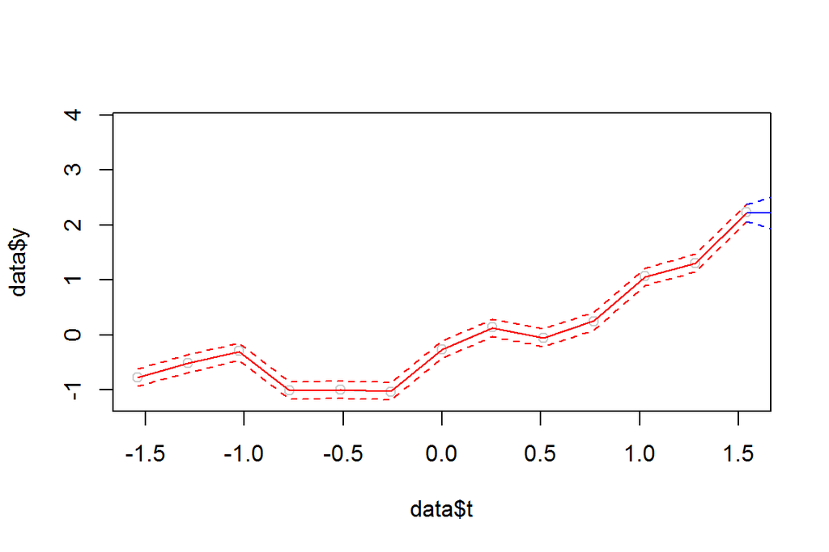

```r
#Predictions
out.yf<-out.sum[grep("yf1",rownames(out.sum)),]
ymin<-min(data$y[1:(n-2)],out.yf[,c(1,3,7)])
ymax<-max(data$y[1:(n-2)],out.yf[,c(1,3,7)])
par(mfrow=c(1,1))
#t vs y
par(mfrow=c(1,1))
plot(data$t,data$y,type="b",col="grey80",ylim=c(ymin,ymax))
lines(data$t,out.yf[1:n,1],col=2)
lines(data$t,out.yf[1:n,3],col=2,lty=2)
lines(data$t,out.yf[1:n,7],col=2,lty=2)
lines(data$t[n]:(data$t[n]+m),out.yf[n:(n+m),1],col=4)
lines(data$t[n]:(data$t[n]+m),out.yf[n:(n+m),3],col=4,lty=2)
lines(data$t[n]:(data$t[n]+m),out.yf[n:(n+m),7],col=4,lty=2)
```

Medias:

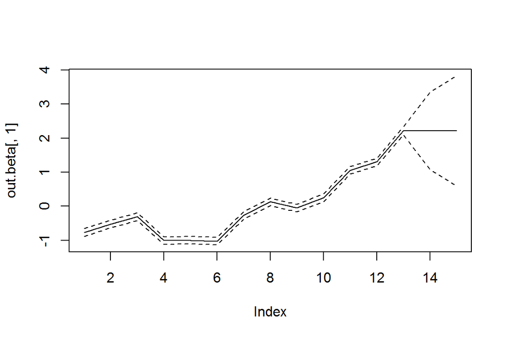

```r
#betas
out.beta<-out.sum[grep("beta",rownames(out.sum)),]
ymin<-min(out.beta[,c(1,3,7)])
ymax<-max(out.beta[,c(1,3,7)])
plot(out.beta[,1],type="l",ylim=c(ymin,ymax))
lines(out.beta[,3],lty=2)
lines(out.beta[,7],lty=2)
```

### Ejercicio aumentando el numero de “0’s” en la a priori

```r
inits<-function(){list(beta=rep(0,n+m),tau.y=1,yf1=rep(0,n+m))}
parameters<-c("beta","tau.y","tau.b","yf1")
ej7b_1.sim<-jags(data,inits,parameters,model.file="Ej7b_1.txt",
               n.iter=50000,n.chains=1,n.burnin=5000,n.thin=1)
```

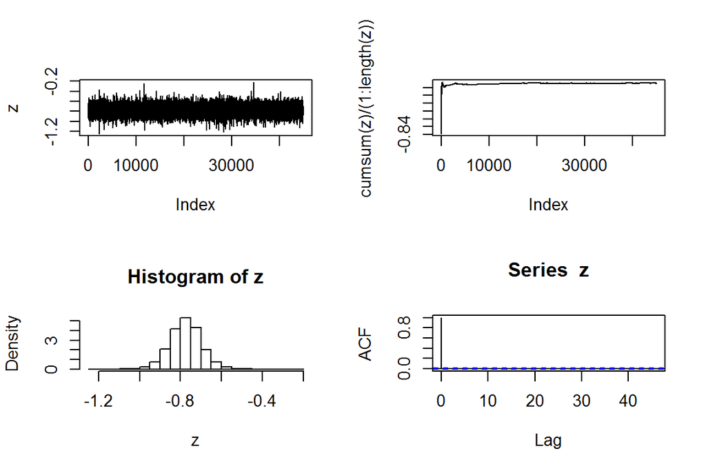

```r
out<-ej7b_1.sim$BUGSoutput$sims.list

z<-out$yf1[,1]
par(mfrow=c(2,2))
plot(z,type="l")
plot(cumsum(z)/(1:length(z)),type="l")
hist(z,freq=FALSE)
acf(z)
```

```r
#Resumen de estimadores
out.sum<-ej7b_1.sim$BUGSoutput$summary
#Tabla resumen
out.sum.t<-out.sum[grep("beta",rownames(out.sum)),c(1,3,7)]
out.sum.t<-cbind(out.sum.t,apply(out$beta,2,prob))
dimnames(out.sum.t)[[2]][4]<-"prob"
print(out.sum.t)
```

```
##                 mean        2.5%       97.5%         prob
## beta[1]  -0.77455165 -0.88441385 -0.66631546 4.444444e-05
## beta[2]  -0.52195205 -0.62966837 -0.41461806 2.222222e-05
## beta[3]  -0.30628490 -0.41453881 -0.19719897 4.444444e-05
## beta[4]  -1.01035639 -1.11803445 -0.90290749 0.000000e+00
## beta[5]  -1.00089211 -1.10936457 -0.89302783 2.222222e-05
## beta[6]  -1.02494776 -1.13309849 -0.91611868 0.000000e+00
## beta[7]  -0.26909358 -0.37664610 -0.16172960 1.333333e-04
## beta[8]   0.12770857  0.01991055  0.23451972 1.184444e-02
## beta[9]  -0.05284926 -0.16114890  0.05638032 1.522000e-01
## beta[10]  0.25089431  0.14129337  0.35829523 8.888889e-05
## beta[11]  1.05535586  0.94790752  1.16370931 0.000000e+00
## beta[12]  1.30752758  1.19969113  1.41459387 0.000000e+00
## beta[13]  2.21906341  2.11054219  2.32719044 0.000000e+00
## beta[14]  2.21516286  1.11211932  3.31664984 5.333333e-04
## beta[15]  2.21990919  0.67027003  3.79362366 4.333333e-03
```

```r
#DIC
out.dic<-ej7b_1.sim$BUGSoutput$DIC
print(out.dic)
```

```
## [1] -12.17164
```

Predicciones:

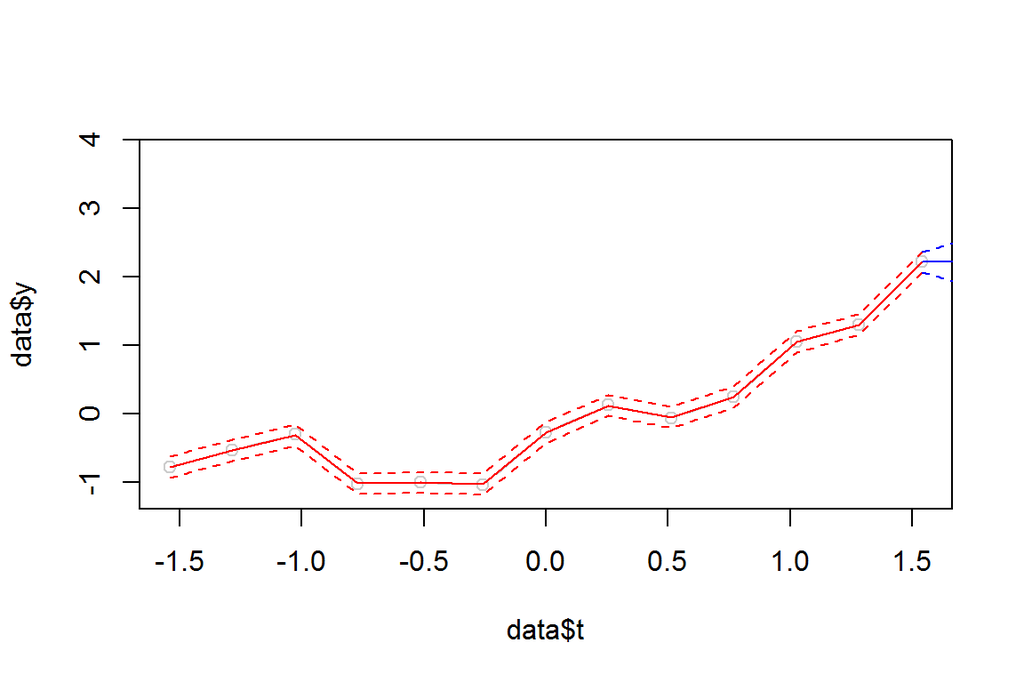

```r
#Predictions
out.yf<-out.sum[grep("yf1",rownames(out.sum)),]
ymin<-min(data$y[1:(n-2)],out.yf[,c(1,3,7)])
ymax<-max(data$y[1:(n-2)],out.yf[,c(1,3,7)])
par(mfrow=c(1,1))
#t vs y
par(mfrow=c(1,1))
plot(data$t,data$y,type="b",col="grey80",ylim=c(ymin,ymax))
lines(data$t,out.yf[1:n,1],col=2)
lines(data$t,out.yf[1:n,3],col=2,lty=2)
lines(data$t,out.yf[1:n,7],col=2,lty=2)
lines(data$t[n]:(data$t[n]+m),out.yf[n:(n+m),1],col=4)
lines(data$t[n]:(data$t[n]+m),out.yf[n:(n+m),3],col=4,lty=2)
lines(data$t[n]:(data$t[n]+m),out.yf[n:(n+m),7],col=4,lty=2)
```

Medias:

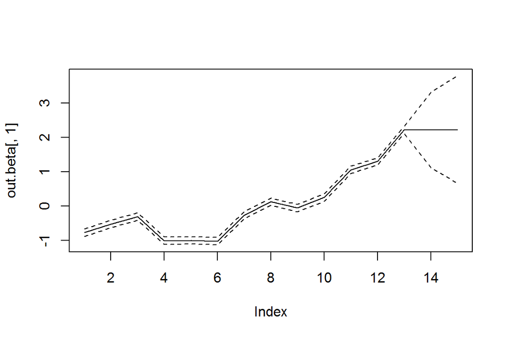

```r
#betas
out.beta<-out.sum[grep("beta",rownames(out.sum)),]
ymin<-min(out.beta[,c(1,3,7)])
ymax<-max(out.beta[,c(1,3,7)])
plot(out.beta[,1],type="l",ylim=c(ymin,ymax))
lines(out.beta[,3],lty=2)
lines(out.beta[,7],lty=2)
```

### Ejercicio aumentamos un “0” mas en la a priori

```r
inits<-function(){list(beta=rep(0,n+m),tau.y=1,yf1=rep(0,n+m))}
parameters<-c("beta","tau.y","tau.b","yf1")
ej7b_2.sim<-jags(data,inits,parameters,model.file="Ej7b_2.txt",
               n.iter=50000,n.chains=1,n.burnin=5000,n.thin=1)
```

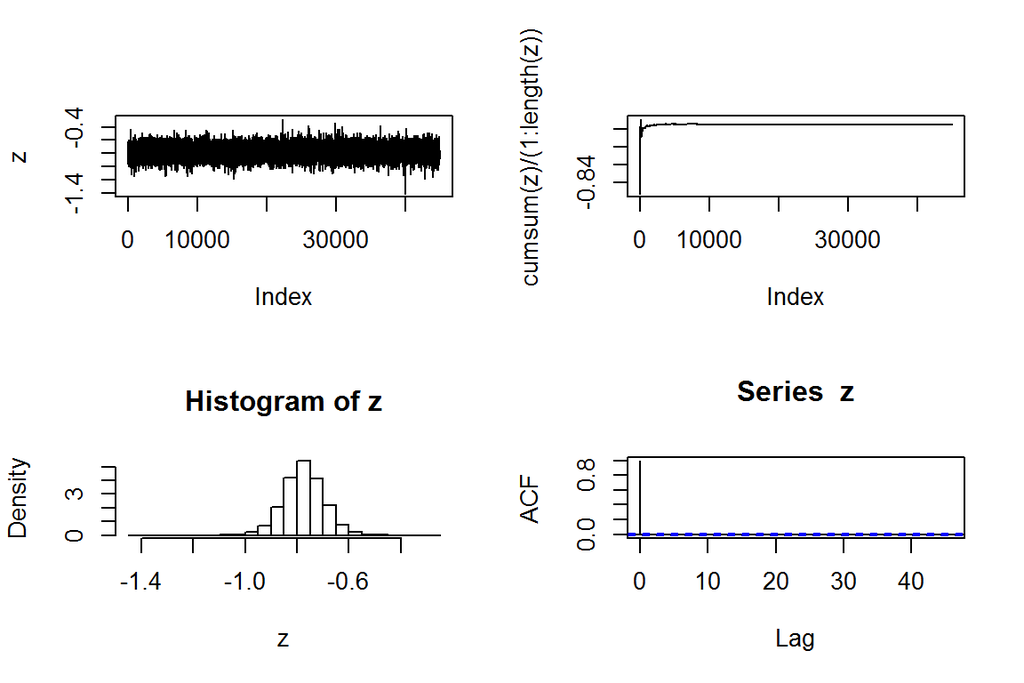

```r
out<-ej7b_2.sim$BUGSoutput$sims.list

z<-out$yf1[,1]
par(mfrow=c(2,2))
plot(z,type="l")
plot(cumsum(z)/(1:length(z)),type="l")
hist(z,freq=FALSE)
acf(z)
```

```r
#Resumen de estimadores
out.sum<-ej7b_2.sim$BUGSoutput$summary
#Tabla resumen
out.sum.t<-out.sum[grep("beta",rownames(out.sum)),c(1,3,7)]
out.sum.t<-cbind(out.sum.t,apply(out$beta,2,prob))
dimnames(out.sum.t)[[2]][4]<-"prob"
print(out.sum.t)
```

```
##                 mean        2.5%       97.5%         prob
## beta[1]  -0.77410676 -0.88330305 -0.66572740 2.222222e-05
## beta[2]  -0.52142761 -0.63034951 -0.41133912 4.444444e-05
## beta[3]  -0.30695607 -0.41536187 -0.19939106 6.666667e-05
## beta[4]  -1.00974767 -1.11877822 -0.90202452 0.000000e+00
## beta[5]  -1.00062816 -1.10994755 -0.89256056 0.000000e+00
## beta[6]  -1.02490991 -1.13405696 -0.91727575 0.000000e+00
## beta[7]  -0.26893676 -0.37756203 -0.16141344 1.111111e-04
## beta[8]   0.12826221  0.01895695  0.23655561 1.202222e-02
## beta[9]  -0.05269203 -0.16063658  0.05471184 1.539111e-01
## beta[10]  0.25066465  0.14222228  0.35859874 1.111111e-04
## beta[11]  1.05570229  0.94660446  1.16513204 0.000000e+00
## beta[12]  1.30773563  1.19728976  1.41669340 0.000000e+00
## beta[13]  2.21890852  2.10996547  2.32844403 0.000000e+00
## beta[14]  2.21750764  1.11951698  3.32289390 4.888889e-04
## beta[15]  2.21761670  0.66038331  3.78309642 4.311111e-03
```

```r
#DIC
out.dic<-ej7b_2.sim$BUGSoutput$DIC
print(out.dic)
```

```
## [1] -11.94004
```

Predicciones:

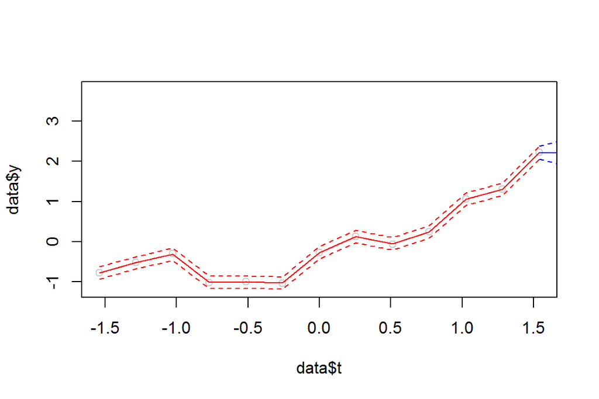

```r
#Predictions
out.yf<-out.sum[grep("yf1",rownames(out.sum)),]
ymin<-min(data$y[1:(n-2)],out.yf[,c(1,3,7)])
ymax<-max(data$y[1:(n-2)],out.yf[,c(1,3,7)])
par(mfrow=c(1,1))
#t vs y
par(mfrow=c(1,1))
plot(data$t,data$y,type="b",col="grey80",ylim=c(ymin,ymax))
lines(data$t,out.yf[1:n,1],col=2)
lines(data$t,out.yf[1:n,3],col=2,lty=2)
lines(data$t,out.yf[1:n,7],col=2,lty=2)
lines(data$t[n]:(data$t[n]+m),out.yf[n:(n+m),1],col=4)
lines(data$t[n]:(data$t[n]+m),out.yf[n:(n+m),3],col=4,lty=2)
lines(data$t[n]:(data$t[n]+m),out.yf[n:(n+m),7],col=4,lty=2)
```

Medias:

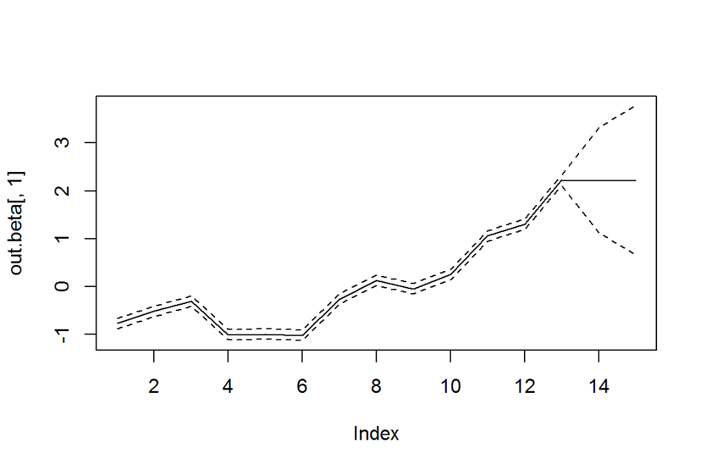

```r
#betas
out.beta<-out.sum[grep("beta",rownames(out.sum)),]
ymin<-min(out.beta[,c(1,3,7)])
ymax<-max(out.beta[,c(1,3,7)])
plot(out.beta[,1],type="l",ylim=c(ymin,ymax))
lines(out.beta[,3],lty=2)
lines(out.beta[,7],lty=2)
```

### Conclusiones:

Concluimos tal como lo vimos en clase, que conforme nuestra distribucion a priori es menos informativa, nuestros resultados se ajustan mas a la prediccion y podemos obtener resultados con menor varianza. Partiendo de uno de los propositos de las regresion que es obtener predicciones futuras, queremos buscar las que nos brinden mas confianza a traves de menos sesgo o error en la predicción.